# California Halibut - Southern Stock

### Reference Point Observations

#### Sampled Parameters

Histograms of 48 simulations of bias in observed FMSY/M (`FMSY_Mbias`), BMSY/B0 (`BMSY_B0bias`), reference index (`Irefbias`), reference abundance (`Brefbias`) and reference catch (`Crefbias`), with vertical colored lines indicating 3 randomly drawn values:

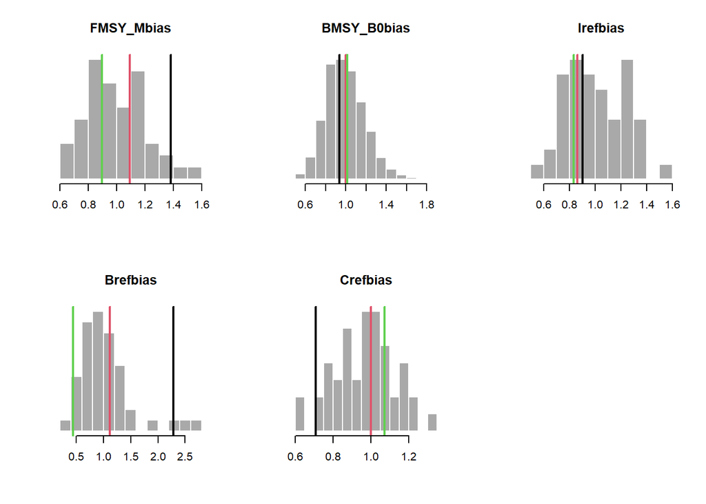

# Imp Parameters

Implementation error was not included in DLMtool at the time this OM was built. Here it is assumed that management is implemented perfectly. These values may be updated when the OM is revised in 2018.

### Output Control Implementation Error: TACFrac, TACSD

**TACFrac**: Mean fraction of TAC taken. Uniform distribution lower and upper bounds. Positive real number.

Specified Value(s): 1, 1

Borrowed from Perfect_Imp

**TACSD**: Log-normal coefficient of variation in the fraction of Total Allowable Catch (TAC) taken. Uniform distribution lower and upper bounds. Non-negative real numbers.

Specified Value(s): 0, 0

Borrowed from Perfect_Imp

### Effort Control Implementation Error: TAEFrac, TAESD

**TAEFrac**: Mean fraction of TAE taken. Uniform distribution lower and upper bounds. Positive real number.

Specified Value(s): 1, 1

Borrowed from Perfect_Imp

**TAESD**: Log-normal coefficient of variation in the fraction of Total Allowable Effort (TAE) taken. Uniform distribution lower and upper bounds. Non-negative real numbers.

Specified Value(s): 0, 0

Borrowed from Perfect_Imp

### Size Limit Control Implementation Error: SizeLimFrac, SizeLimSD

**SizeLimFrac**: The real minimum size that is retained expressed as a fraction of the size of retention. Uniform distribution lower and upper bounds. Positive real number.

Specified Value(s): 1, 1

Borrowed from Perfect_Imp

**SizeLimSD**: Log-normal coefficient of variation controlling mismatch between a minimum size limit and the real minimum size retained. Uniform distribution lower and upper bounds. Non-negative real numbers.

Specified Value(s): 0, 0

Borrowed from Perfect_Imp